# Mechanistic Presence-Only Data Model Estimates Abundance Absolutely

Gregory Penn

06 December, 2021

Abstract

Species distribution modeling with presence-only or presence-background data requires additional information in order to estimate abundance in absolute terms, e.g. population density or probability of occurrence. Current methods generally require that this information be prior knowledge of species prevalence (i.e. unconditional species abundance), which is often unknown. However, while the requirement of additional information is not flexible, the source of that information is; it need not be species prevalence. We illustrate this with a model of presence-only data as the result of joint latent processes of species occurrence and human observation. We show that our model can estimate species abundance absolutely from presence-only data if parameters of the observation process are known or can be estimated.

# 1 Introduction

Note: This document is a work in progress currently at an early stage. As such, it contains notes regarding what still needs to be done and how those things might be approached.

## 1.1 Motivation

Questions of where species occur, in what abundance, and why are central to ecology and biological resource management. Answering these questions is the goal of species distribution models (SDMs), which generally model species abundance (potential or actual) as a function of environmental covariates. However, fitting models of abundance requires having estimates of abundance, and while environmental covariate data are often readily available, abundance data usually are not. Lacking abundance data from systematic biological surveys, researchers often rely on commonly available presence-only data, often referred to as presence-background data when combined with covariate data for additional locations. Presence-only and presence-background data are records that the presence of a species was observed at some place and time, but without explicit information about where it was absent or about its abundance.

While it is intuitively clear that presence-only data contain valuable information about species distributions, they are not samples of species abundance and cannot be used to estimate abundance without additional information (Ward et al. 2009; Hastie and Fithian 2013). Current methods require that the additional information be prior knowledge of species prevalence, i.e. unconditional abundance, which is often unknown. Lacking knowledge of species prevalence, most studies resort to estimating abundance as a relative quantity, proportional to the abundance of observations. Unfortunately, although relative estimates of abundance can provide useful information for comparing different geographic areas and for comparing the effects of covariates within a single study, they cannot be used to compare different species or the results of different studies for the same species. Critically, they also cannot distinguish whether a species is common or rare. Even when relative estimates are sufficient for answering a particular research question, methods providing absolute estimates are preferable because they contain more information and can always be used to derive relative estimates if desired. As a result of these limitations, estimates of relative abundance are often unsatisfactory.

## 1.2 This work

We have developed a method that estimates abundance in absolute terms from presence-only data, using information about the observation process for the required constraints. A relatively simple binomial data model for the observation process demonstrates that in the special case where sampling effort and detection probability are known, abundance can be estimated analytically by maximum-likelihood. A measure of uncertainty in this estimate could be provided by a Cramér Rao bound, after determining whether the estimator is biased. A Bayesian model provides more robust and intuitive handling of inferential uncertainty by accounting for uncertainty in model inputs such as detection probability or sampling effort. The posterior distribution of abundance can be sampled empirically from the Bayesian model using Markov Chain Monte Carlo methods, however the model would be more useful if we could develop an analytical solution to the posterior. That work is currently in progress and probably comes down to solving some integrals.

# 2 Model Description

Our hierarchical data model includes sub-models for the processes of observation and occurrence. We represent species occurrence as the result of a spatial Poisson point-process with intensity $\xi$, a rate parameter that may be interpreted as the expected number of occurrences per unit area, i.e., population density.

We model the observation process as a binomial experiment where $n$ observations (trials) represent sampling effort, $z$ detections (successes) represent the number of presence only records in a region, and the probability of detection for each observation is $p_\text{detect}$. We define an observation as a binary event that either results in the creation of a single presence-only datum (henceforth a detection) or fails to do so. We model the spatial extent of an observation as a disk with area $a = \pi r^2$, where $r$ represents a distance within which an occurrence can attract the attention of an observer. For simplicity, we say that only occurrences on the observed disk are within view, and that all of those are equally visible. The expected number of occurrences in view is given by $a \xi$. The detection probability for an observation event is represented by parameter $p_\text{detect}$ (equation (2.1)), which is a function of the number of occurrences within view and the probability $p_1$ that a single occurrence within view would trigger detection. More precisely, we say that each occurrence within view is “noticed” with equal probability $p_1$ (a beta distributed random variable), and that if one or more occurrences are noticed then one is chosen at random and its location recorded as a presence-only datum, resulting in a detection for that observation. A derivation of $p_\text{detect}$ is provided in Appendix A.

$$\begin{equation}
p_{\text{detect}} = 1 - e^{-p_1 \xi a}
\tag{2.1}
\end{equation}$$

Any bounded region of the landscape will contain a number $z$ of presence-only records (i.e., detections) resulting from $n$ independent observation events, each with detection probability $p_\text{detect}$. Thus $z$ has a binomial probability distribution, with probability mass function

$$\begin{equation}
\Pr(z \mid \xi, p_1) = \binom{n}{z} \left(1 - e^{-p_1 \xi a}\right)^{z} \left(e^{-p_1 \xi a}\right)^{(n - z)}
\tag{2.2}
\end{equation}$$

The likelihood function for $\xi$ is

$$\begin{equation}
\mathcal{L}(\xi) \propto
\binom{n}{z} \left(1 - e^{-p_1 \xi a}\right)^z \left(e^{-p_1 \xi a}\right)^{(n - z)}
\tag{2.3}
\end{equation}$$

And the maximum likelihood value of $\xi$ is given by

$$\begin{equation}
\text{Max}~\mathcal{L}\left(\xi\right) = \log\left(\frac{z}{n - z} + 1\right) \frac{1}{ p_1 a}
\end{equation}$$

for $z \neq n$ and $p_1 a > 0$. A derivation of the maximum likelihood is given in Appendix B. Empirical validation via simulation is given in Appendix C.

Table 2.1 provides a quick reference to model variables and their interpretations.

Table 2.1: A summary of model variables and their interpretations.

| Variable | Domain | Interpretation |
| --- | --- | --- |
| $z$ | Non-negative integer $\leq n$ | Number of detections |
| $n$ | Non-negative integer | Number of observations |
| $p_\text{detect}$ | $0 \leq p_\text{detect} \leq 1$ | Probability that an observation results in detection |
| $\xi$ | $\xi \geq 0$ | Poisson rate parameter, i.e. population density |
| $\eta$ | $\eta > 0$ | Shape parameter for gamma prior distribution of $\xi$ |
| $\tau$ | $\tau > 0$ | Rate parameter for gamma prior distribution of $\xi$ |
| $a$ | $a \geq 0$ | Areal extent of obervations $a = \pi r^2$ |
| $r$ | $r \geq 0$ | Radius of obervation disk |
| $p_1$ | $0 \leq p_1 \leq 1$ | Probability of a single observable occurrance triggering detection |

## 2.1 Bayesian model

**NOTES:** All the math in Section 2.1 needs to be checked. For now, we consider sampling effort (i.e. binomial trials) $n$ to be a known constant, though the model should be generalized with $n$ as a random variable. The number of binomial successes $z$ is modeled as a random variable, however this quantity is generally fixed as data. To keep the notation legible, we ignore fixed parameters $a$ and $n$ initially, re-introducing them when details require.

### 2.1.1 Priors

For $\xi$ we use a gamma prior distribution with shape parameter $\eta$, rate parameter $\tau$, and probability density function

$$\begin{equation}
\Pr(\xi) = \frac{\eta^\tau}{\Gamma(\eta)} \xi^{\eta - 1} e^{-\tau \xi}
\tag{2.4}
\end{equation}$$

For $p_1$ we use a beta prior distribution with shape parameters $\alpha$ and $\beta$ and probability density function

$$\begin{equation}
\Pr(p_1) = p_1^{\alpha - 1} (1 - p_1)^{\beta - 1}\frac{\Gamma(\alpha + \beta)}{\Gamma(\alpha) \cdot \Gamma(\beta)}
\tag{2.5}
\end{equation}$$

where $\Gamma$ is the gamma function $\Gamma(x) = (x - 1)!$. Because $p_1$ and $\xi$ are independent, their joint prior is

$$\begin{equation}
\Pr(\xi, p_1) =
\left[\frac{\eta^\tau}{\Gamma(\eta)} \xi^{\eta - 1} e^{-\tau \xi} \right]
\cdot \left[p_1^{\alpha - 1} (1 - p_1)^{\beta - 1}\frac{\Gamma(\alpha + \beta)}{\Gamma(\alpha) \cdot \Gamma(\beta)}\right]
\tag{2.6}
\end{equation}$$

### 2.1.2 Marginal posterior of $\xi$

The posterior joint distribution of $\xi$ and $p_1$ is

$$\begin{equation}
\Pr(\xi, p_1 \mid z) = c \cdot \Pr(z \mid \xi, p_1) \cdot \Pr(xi, p_1)
\tag{2.7}
\end{equation}$$

with the normalizing constant

$$\begin{equation}
c = \frac{1}{\int_{\xi = 0}^{\infty} \int_{p_1 = 0}^{1} \Pr(z \mid \xi, p_1) \cdot \Pr(xi, p_1) \, d p_1 \, d \xi}
\end{equation}$$

The marginal distribution of $\xi$ given $z$ integrates the joint posterior (2.7) across the distribution of $p_1$.

$$\begin{equation}
\Pr(\xi \mid z) = c \cdot \int_{p_1 = 0}^{1} \Pr(z \mid \xi, p_1) \cdot \Pr(xi, p_1) \, d p_1
\tag{2.8}
\end{equation}$$

**Note:** The generalization to model $n$ as a random variable would introduce another integral here across $n$. Informative priors may adequately constrain the general model, but that remains to be verified.

To make the integrals more comprehensible, we re-factor the gory details as

$$\begin{align}
\Pr(z \mid \xi, p_1) \cdot \Pr(xi, p_1) &=
\overbrace{
\binom{n}{z} \left(1 - e^{-p_1 \xi a}\right)^{z} \left(e^{-p_1 \xi a}\right)^{(n - z)}
}^{\Pr(z \mid \xi, p_1)}
\cdot \overbrace{
\left[\frac{\eta^\tau}{\Gamma(\eta)} \cdot \xi^{\eta - 1} e^{-\tau \xi} \right]
}^{\Pr(\xi)}
\cdot \overbrace{
\left[p_1^{\alpha - 1} (1 - p_1)^{\beta - 1}
\cdot \frac{\Gamma(\alpha + \beta)}
{\Gamma(\alpha) \cdot \Gamma(\beta)}\right]
}^{\Pr(p_1)} \\
&= f(\theta) \cdot g(\theta_\xi) \cdot h(\theta_{p_1}) \cdot k(\theta_{\xi, p_1})
\tag{2.9}
\end{align}$$

Where

$$\begin{align}
f(\theta)
&= \binom{n}{z} \cdot \frac{\eta^\tau}{\Gamma(\eta)}
\cdot \frac{\Gamma(\alpha + \beta)}{\Gamma(\alpha) \cdot \Gamma(\beta)} \qquad\qquad\qquad \text{with}
&&\theta = \{n, z, \eta, \tau, \alpha, \beta\} \\
g(\theta_\xi) &= \xi^{\eta - 1} e^{-\tau \xi}
&&\theta_\xi = \{\xi, \eta, \tau\} \\
h(\theta_{p_1}) &= p_1^{\alpha - 1} (1 - p_1)^{\beta - 1} \quad
&&\theta_{p_1} = \{p_1, \alpha, \beta\} \\
k(\theta_{\xi, p_1}) &= \left(1 - e^{-p_1 \xi a}\right)^{z} \left(e^{-p_1 \xi a}\right)^{(n - z)} \quad
&&\theta_{\xi, p_1} = \{p_1, \xi, a, n, z\}
\tag{2.10}
\end{align}$$

Substituting $f(\theta) \cdot g(\theta_\xi) \cdot h(\theta_{p_1}) \cdot k(\theta_{\xi, p_1})$ from (2.9) into the marginal distribution of $\xi$ from (2.8) yields

$$\begin{align}
\Pr(\xi \mid z)
&= c' \cdot g(\theta_\xi)
\cdot \int_{p_1 = 0}^{1}
h(\theta_{p_1}) \cdot k(\theta_{\xi, p_1})
\, d p_1
\tag{2.11}
\end{align}$$

where $c'$ is

$$\begin{equation}
c' = \frac{1}{\int_{\xi = 0}^{\infty} g(\theta_\xi)
\cdot \int_{p_1 = 0}^{1} h(\theta_{p_1}) \cdot k(\theta_{\xi, p_1}) \, d p_1 \, d \xi}
\tag{2.12}
\end{equation}$$

Note that $f(\theta)$ cancels out of the equation.

### 2.1.3 Marginal Moments of $\xi$

The $j$th moment around the origin of $\xi$ is

$$\begin{align}
\mathrm{E}(\xi \mid z)
&= \int_{xi = 0}^{\infty} \xi^n \cdot \Pr(\xi \mid z) \, d \xi \\
&= c' \cdot \int_{xi = 0}^{\infty}
\xi^j \cdot g(\theta_\xi) \cdot \int_{p_1 = 0}^{1}
h(\theta_{p_1}) \cdot k(\theta_{\xi, p_1})
\, d p_1 \, d \xi
\tag{2.13}
\end{align}$$

## 2.2 Analytical Solution of a Special Case

No general analytical solution is available for this model, due to intractable integrals. However, a special case can be solved as an example. Convenient priors and fixed constants allow simplification of a special case. Assume $z = 1$, $n - z = 1$, $a = 1$, $p_1 \sim \mathrm{Beta(\alpha = 1, \beta = 1)}$, and $\xi \sim \mathrm{Gamma}(\eta = 1, \tau = 1)$.

The Bayes-Laplace uniform prior $p_1 \sim \mathrm{Beta}(\alpha = 1, \beta = 1)$ simplifies

$$\begin{equation}
h(\theta_{p_1}) = p_1^{\alpha - 1} (1 - p_1)^{\beta - 1} \rightarrow 1
\tag{2.14}
\end{equation}$$

Fixing $n = n - z = 1$ and $a = 1$ simplifies

$$\begin{equation}
k(\theta_{\xi, p_1}) = \left(1 - e^{-p_1 \xi a}\right)^{z} \left(e^{-p_1 \xi a}\right)^{(n - z)}
\rightarrow \left(1 - e^{-p_1 \xi}\right) e^{-p_1 \xi}
\tag{2.15}
\end{equation}$$

The prior $\xi \sim \mathrm{Gamma}(\eta = 1, \tau = 1)$ simplifies

$$\begin{equation}
g(\theta_{\xi}) = \xi^{\eta - 1} e^{-\tau \xi} \rightarrow e^{-\xi}
\tag{2.16}
\end{equation}$$

The inner integral from (2.13) evaluates to

$$\begin{align}
\int_{p_1 = 0}^{1}
h(\theta_{p_1}) \cdot k(\theta_{\xi, p_1})
\, d p_1
&= \int_{p_1 = 0}^{1}
\left(1 - e^{-p_1 \xi}\right) e^{-p_1 \xi}
\, d p_1 \\
&= \frac{1 - 2 e^{-\xi} + e^{-2 \xi}}
{2 \xi}
\tag{2.17}
\end{align}$$

#### First moment

The first moment of $\xi$, i.e. $j = 1$, has the outer integral (from (2.13))

$$\begin{equation}
\int_{xi = 0}^{\infty}
\xi^1 e^{-\xi}
\cdot \frac{1 - 2 e^{-\xi} + e^{-2 \xi}}{2 \xi}
\, d \xi
\tag{2.18}
\end{equation}$$

$$\begin{equation}
\mathrm{E}(\xi) = -\frac{1}{3 \, {\left(\log\left(3\right) - 2 \, \log\left(2\right)\right)}}
\approx 1.1587
\tag{2.19}
\end{equation}$$

The maximum likelihood value of $\xi$ under this parameterization is 1.3863. The difference between the ML value and the Bayesian expectation may be attributed to the relative weights of the prior (1 observation) and the data (2 observations). The prior $\Gamma(1, 1)$ carries the weight of a single observation of $\xi$ and has expectation $\mathrm{E}(\xi) = 1$, so while in many cases it would be considered weakly informative, its weight is non-trivial in this case.

#### Second moment

The second moment of $\xi$ is

$$\begin{equation}
\mathrm{E}(\xi^2)
= -\frac{11}{18 \, {\left(\log\left(3\right) - 2 \, \log\left(2\right)\right)}}
\approx 2.1243
\tag{2.20}
\end{equation}$$

#### Variance

The variance is

$$\begin{equation}
\mathrm{E}(\xi^2) - \left(\mathrm{E}(\xi)\right)^2 = 2.1243 - 1.1587^2 = 0.7817
\tag{2.21}
\end{equation}$$

#### Posterior distribution

The gamma distribution of the posterior is parameterized by solving the system of equations for $\eta$ and $\tau$

$$\begin{align}
\frac{\eta}{\tau} &= \mathrm{E}(\xi) \\
\frac{\eta}{\tau^2} &= \mathrm{Var}(\xi)
\tag{2.22}
\end{align}$$

resulting in the posterior distribution $\Gamma(\eta = 1.718, \tau = 1.482)$.

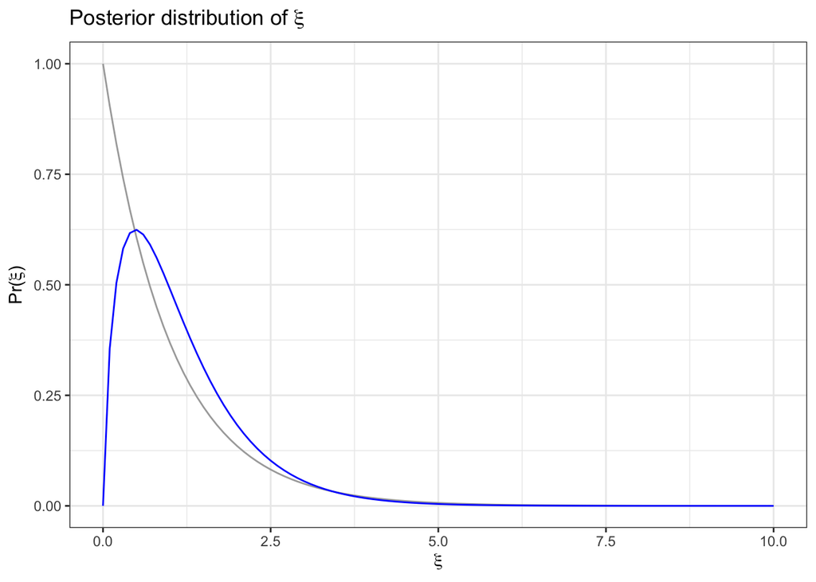

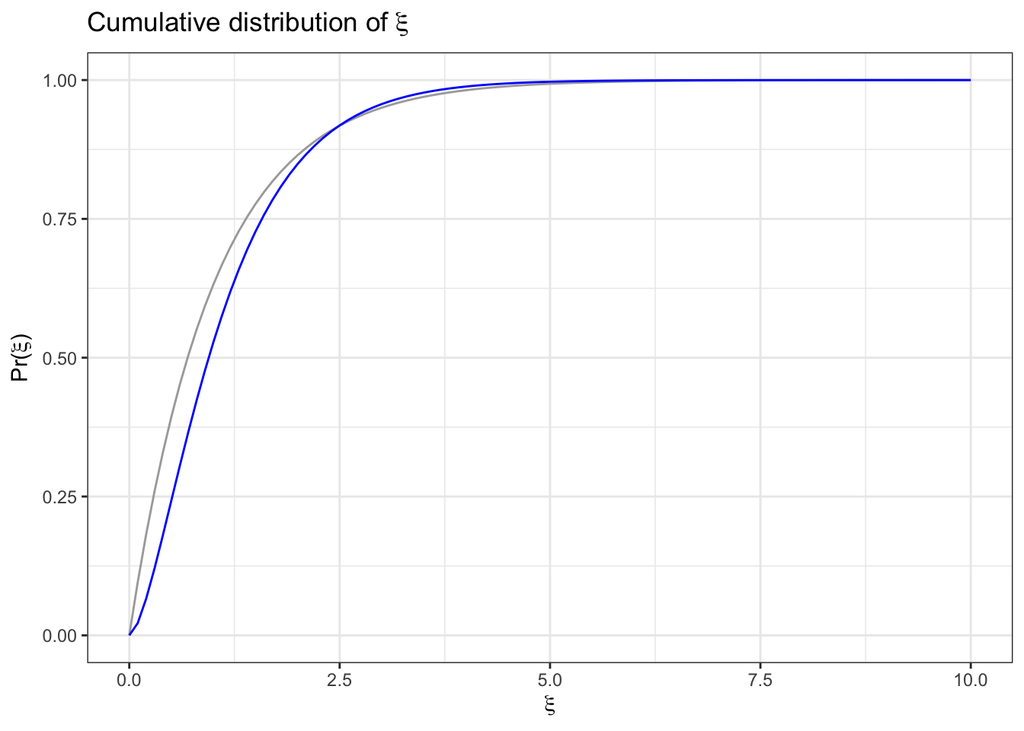

Figure 2.1: Prior distribution of $\xi$ is grey, posterior is blue.

## 2.3 Uncertainty

Uncertainty about the observation process, the variance of $p_1$, propagates to the model’s inference of abundance $\xi$. To investigate how $\mathrm{Var}(p_1)$ affects $\mathrm{Var}(\xi)$ we simulated data as the expected value of $z$, the number of presence-only records, given $n$ observations, a distribution of $p_1$ with the true value as its mean, and a fixed value of $\xi = 0.25\,\mathrm{m}^2$ for abundance, roughly the density of creosote bush in parts of southern New Mexico where it is common. We inferred $\xi$ from the simulated data using Markov chain Monte Carlo (MCMC) sampling. The beta distribution of $p_1$ was sampled with a posterior predictive sampler. We used the weakly informative prior $\xi \sim \Gamma(0.5, 0.5\xi)$ following Gelman (2006) and a random walk sampler for the posterior distribution of $\xi$. MCMC sampling was implemented using the R package NIMBLE (TODO: citations needed for R and NIMBLE).

Figure 2.2 illustrates an exponential relationship between the variance of $p_1$ and the variance of $\xi$. With sufficiently high variance in $p_1$ the posterior sensibly fails to converge, as we essentially have no idea whether we would have detected any occurrences that were present and the constraint provided by knowledge of the observation process evaporates.

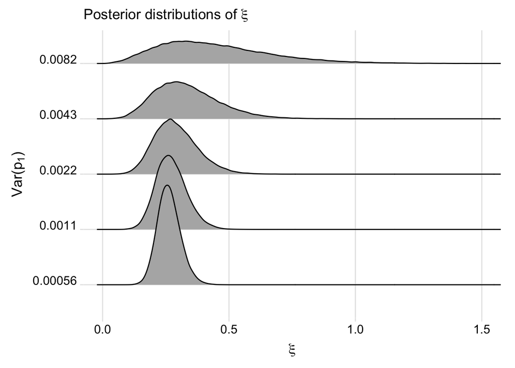

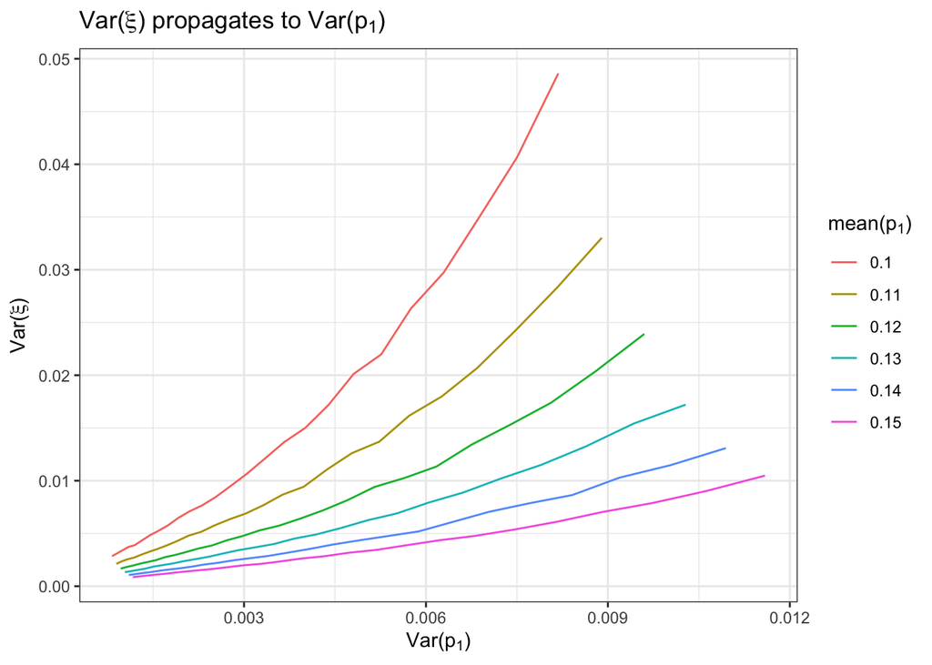

Figure 2.2: $\xi$ inferred from distributions of $p_1$ with the true value as its mean and a range of variance. Left panel: Posterior distributions of $\xi$ with true $p_1 = 0.1$. From top to bottom, the variance of $p_1$ is based on a weight of evidence representing 10, 20, 40, 80, and 160 observations. Each density plot is essentially a point along the uppermost curve in the right panel. Right panel: Each curve represents distributions of $p_1$ with a single mean, indicated in the legend, and a range of variance. The variance of $p_1$ at the high end of each curve represents an estimate based on 10 observations. Each inflection point represents the evidence of 10% more observations, ending with 108 observations where the variance is lowest for each curve.

## 2.4 Bias

The estimator $\xi$ show increasingly positive bias with increasing variance in $p_1$, at least in the simulations shown so far. However, that may be a result of a random walk away from the wall at $\xi = 0$, which is relatively close to the true value of $\xi = 0.25$.

TODO: Reparameterize the spatial scale to a kilometer base unit, as that would move $\xi$ far from zero, and see whether the estimator is still biased.

# 3 References

Gelman, Andrew. 2006. “Prior distributions for variance parameters in hierarchical models (comment on article by Browne and Draper).” *Bayesian Analysis* 1 (3): 515–34. https://doi.org/10.1214/06-BA117A.

Hastie, Trevor, and Will Fithian. 2013. “Inference from Presence-Only Data; the Ongoing Controversy.” *Ecography* 36 (8): 864–67. https://doi.org/10.1111/j.1600-0587.2013.00321.x.

Ward, Gill, Trevor Hastie, Simon Barry, Jane Elith, and John R. Leathwick. 2009. “Presence-Only Data and the EM Algorithm.” *Biometrics* 65 (2): 554–63. https://doi.org/10.1111/j.1541-0420.2008.01116.x.

# A Derivation of $p_{\text{detect}}$

For a given observation, the expected number of occurrences in view is given by $\lambda = a \xi$. Let
$$\begin{align}
p_k &= 1 - (1 - p)^k \text{, and} \\
\Pr(p_k) &= \mathrm{Poisson}(k, \lambda) ~ \forall k \in \{0, 1, 2, \dots \} \\
&= \frac{\lambda^k e^{-\lambda}}{k!}
\end{align}$$
then
$$\begin{align}
\Pr(p_k) &= \sum_{0}^\infty p_k \Pr(p) \\
&= \sum_{0}^\infty (1 - (1 - p)^k) \cdot \Pr(k) \\
&= \sum_{0}^\infty \Pr(k) - \sum_{0}^\infty (1 - p)^k \cdot \Pr(k) \\
&= 1 - \sum_{0}^\infty (1 - p)^k \cdot \Pr(k) \\
&= 1 - \sum_{0}^\infty (1 - p)^k \cdot \frac{\lambda^k e^{-\lambda}}{k!} \\
&= 1 - \sum_{0}^\infty \frac{(1 - p)^k \lambda^k e^{-\lambda}}{k!} \\
&= 1 - \sum_{0}^\infty \frac{((1 - p) \lambda)^k e^{-\lambda}}{k!} \\
&= 1 - \frac{e^{-\lambda}}{e^{-(1 - p) \lambda}} \sum_{0}^\infty \frac{((1 - p) \lambda)^k e^{-(1 - p) \lambda}}{k!} \\
&= 1 - \frac{e^{-\lambda}}{e^{-(1 - p) \lambda}} \sum_{0}^\infty \mathrm{Poisson}(k | (1 - p) \lambda) \\
&= 1 - \frac{e^{-\lambda}}{e^{-(1 - p) \lambda}} \\
&= 1 - e^{-p \lambda}
\end{align}$$

# B Derivation of Maximum Likelihood

The maximum likelihood value of $\xi$ is found at a root of the partial derivative of the likelihood function with respect to $\xi$.

Let $c = p_1 a$
$$\begin{align}
&\frac{\partial}{\partial \xi} \left(
\binom{n}{z} \left(1 - e^{-c \xi}\right)^z e^{-c \xi (n - z)}
\right) \\
&= \binom{n}{z}
\frac{\partial}{\partial \xi} \left(
\left(1 - e^{-c \xi}\right)^z e^{-c \xi (n - z)}
\right)~\text{constant rule} \\
&= \binom{n}{z} \left(
\frac{\partial}{\partial \xi} \left(
\left(1 - e^{-c \xi}\right)^z
\right) e^{-c \xi (n - z)} +
\frac{\partial}{\partial \xi} \left(
e^{-c \xi (n - z)}
\right) \left(1 - e^{-c \xi}\right)^z
\right) ~ \text{product rule} \\
&= \binom{n}{z} \left(
c z e^{-c \xi} \left(1 - e^{-c \xi}\right)^{z - 1}
e^{-c \xi (n - z)}
-c(n-z)e^{-c \xi \left(n-z\right)}
\left(1 - e^{-c \xi}\right)^z
\right) ~ \text{chain, exponential, and power rules}
\end{align}$$

## B.1 Determination of roots

$$\begin{align}
c z e^{-c \xi} \left(1 - e^{-c \xi}\right)^{z - 1}
e^{-c \xi (n - z)}
-c(n-z)e^{-c \xi \left(n-z\right)}
\left(1 - e^{-c \xi}\right)^z &= 0 \\
c \left(
z e^{-c \xi} \left(1 - e^{-c \xi}\right)^{z - 1}
e^{-c \xi (n - z)}
-(n-z)e^{-c \xi \left(n-z\right)}
\left(1 - e^{-c \xi}\right)^z \right) &= 0
\end{align}$$

The case $c = 0$ is trivial, as it occurs only when the probability of detection is zero regardless of population density, because $p_1 = 0$ or the radius of detectability $r = 0$. So …

$$\begin{align}
z e^{-c \xi} \left(1 - e^{-c \xi}\right)^{z - 1}
e^{-c \xi (n - z)}
&= (n-z)e^{-c \xi \left(n-z\right)}
\left(1 - e^{-c \xi}\right)^z \\
\log\left(
z e^{-c \xi} \left(1 - e^{-c \xi}\right)^{z - 1}
e^{-c \xi (n - z)} \right)
&= \log\left((n-z)e^{-c \xi \left(n-z\right)}
\left(1 - e^{-c \xi}\right)^z \right) \\
\log\left(z\right) \log\left(e^{-c\xi}\right)
\log\left(\left(1 - e^{-c\xi}\right)^{z - 1}\right)
\log\left(e^{-c \xi \left(n - z\right)}\right)
&= \log\left(n - z \right)
\log\left(e^{-c \xi \left(n - z\right)}\right)
\log\left(\left(1 - e^{-c \xi}\right)^z\right) \\
\log\left(z\right) - c \xi + \left(z - 1\right) \log\left(1 - e^{-c \xi}\right) - c \xi \left(n - z\right)
&= \log\left(n - z\right) - c \xi \left(n - z\right) + z \log\left(1 - e^{-c \xi}\right) \\
\log\left(z\right) - c \xi + \left(z - 1\right) \log\left(1 - e^{-c \xi}\right)
&= \log\left(n - z\right) + z \log\left(1 - e^{-c \xi}\right) \\
-c \xi + \left(z - 1\right) \log\left(1 - e^{-c \xi}\right) - z \log\left(1 - e^{-c \xi}\right)
&= \log\left(n - z\right) - \log\left(z\right) \\
-c \xi + z \log\left(1 - e^{-c \xi}\right) - \log\left(1 - e^{-c \xi} \right) - z \log\left(1 - e^{-c \xi}\right)
&= \log\left(n - z\right) - \log\left(z\right) \\
-c \xi - \log\left(1 - e^{-c \xi} \right)
&= \log\left(n - z\right) - \log\left(z\right) \\
c \xi + \log\left(1 - e^{-c \xi}\right)
&= \log\left(\frac{z}{n - z}\right) \\
e^{c \xi} &= \frac{z}{\left(n - z\right) \left(1 - e^{-c \xi}\right)} \\
e^{c \xi} \left(1 - e^{-c \xi}\right) &= \frac{z}{n - z} \\
e^{c \xi} - 1 &= \frac{z}{n - z} \\
c \xi &= \log\left(\frac{z}{n - z} + 1\right) \\
\xi &= \log\left(\frac{z}{n - z} + 1\right) \frac{1}{c}
\end{align}$$

Factoring $c$ back into $p_1 a$ we find

$$\begin{equation}
\text{Max}~\mathcal{L}\left(\xi\right) = \log\left(\frac{z}{n - z} + 1\right) \frac{1}{p_1 a}
\end{equation}$$

# C ML Sanity check

The generative data model consists of draws from a binomial distribution with $n$ trials and probability of success $p_\text{detect}$. For ease of interpretability, we consider the area of detectability as a disk with radius $r$ and area $a = \pi r^2$. To sanity check the analytical solution for the maximum likelihood value of $\xi$, the following R code fixes parameters $n$, $p_1$, $r$ and $xi$ to determine the value of $p_\text{detect}$. The expected value of the binomial distribution of $z$ is then used to find the maximum likelihood value of $\xi$, which is then compared with the value of $\xi$ used to determine the expectation of $z$.

```r
#' Function: Returns the maximum-likelihood value of xi.
#' Args:
#' n A natural number representing sampling effort.
#' z A natural number representing the number of detections.
#' p1 A probability
#' r A positive number representing radius of detectability.
ml_xi <- function (n, z, p1, r) {
  c <- p1 * pi * r^2
  return((log(z/(n - z) + 1))/c)
}

# # Alternative formulations of ml_xi
# ml_xi2 <- function (n, z, p1, r) {
#   c <- p1 * pi * r^2
#   return(-c^(-1)*(log(-z/n + 1)))
# }
#
# ml_xi3 <- function (n, z, p1, r) {
#   c <- p1 * pi * r^2
#   return(-c^(-1)*(log((n - z)/n)))
# }

#' Function: Returns detection probability
#' Args:
#' p1 A probability
#' xi A non-negative real number.
#' r A non-negative number representing radius of detectability.
p_detect <- function (p1, xi, r) {
  p <- 1 - exp(-p1 * xi * pi * r^2)
  return(p)
}

# Fix parameters for generating data
xi <- 100
p1 <- 0.1
r <- 0.1
n <- 10^6

# Number of expected detections
expected_z <- n * p_detect(p1, xi, r)

# Difference between expectation and derived maximum-likelihood
dif <- xi - ml_xi(n, expected_z, p1, r)
dif
```

```
## [1] -2.842171e-14
```

```r
# ml_xi2(n, expected_z, p1, r)
# ml_xi3(n, expected_z, p1, r)
```

The difference between the expected value of $\xi = 100$ and the maximum likelihood value is -2.8421709^{-14}. The difference is very small, so likely the result of rounding error, and so passes the sanity check. I could do something more thorough, like generating a bunch of random values and doing a regression, but I think the ML derivation and sanity check are sufficient at least for now.

# D Simulations

TODO: Get all the simulation code cleaned up into a presentable and reproducible form.

```r
nimbleCode({

  p_detect <- 1 - exp(-p1 * xi * a)

  # Data
  z ~ dbinom(size = n, prob = p_detect)

  # Priors
  xi ~ dgamma(shape = eta, rate = tau)
  p1 ~ dbeta(shape1 = alpha, shape2 = beta)
})
```

# E SageMath

## E.1 Special case 1:

SageMath version 9.4

````python
from sage.symbolic.integration.integral import definite_integral

# Special case 1: alpha = beta = 1, z = n - z = 1, a = 1
xi = var('xi'); assume(xi >= 0)
p1 = var('p1'); assume(p1 >= 0); assume(p1 <=1)

g(xi, tau) = exp(-xi)
k(p1, xi) = (1 - exp(-p1 * xi)) * exp(-p1 * xi)

dp1 = definite_integral(SR(k), p1, 0, 1)
print(latex(dp1))

dxi = definite_integral(SR(xi * g * dp1), xi, 0, oo)
print(latex(dxi))

cprime = 1 / definite_integral(SR(g * dp1), xi, 0, oo)
print(latex(cprime))

expect_xi = cprime * dxi
print(latex(expect_xi))
print(round(expect_xi, 4))```
````